# Who, What, Where, Why, How? Sports

Brady Monks

12/7/2020

I wanted to decipher where professional athletes come from. I started with just a dataset of NBA players but quickly decided that there wasn’t enough data. I was able to find datasets for NFL and MLB players.

## NBA, NFL, and MLB raw Datasets

```r
library(tidyverse)
library(Lahman)
library(sf)
library(readr)
library(USAboundaries)
library(USAboundariesData)
library(maps)
library(leaflet)
library(knitr)


NBA <- read.csv("NBA_players.csv")

kable(NBA[1:4,], caption = "NBA")
```

NBA

| X_id | birthDate | birthPlace | career_AST | career_FG. | career_FG3. | career_FT. | career_G | career_PER | career_PTS | career_TRB | career_WS | career_eFG. | college | draft_pick | draft_round | draft_team | draft_year | height | highSchool | name | position | shoots | weight | X |
| --- | --- | --- | --- | --- | --- | --- | --- | --- | --- | --- | --- | --- | --- | --- | --- | --- | --- | --- | --- | --- | --- | --- | --- | --- |
| heanebr01 | 3-Sep-46 |  | 0.4 | 54.2 |  | 50 | 14 | 8.3 | 2.0 | 0.3 | 0.2 |  | Acadia University | 215th overall | 19th round | Baltimore Bullets | 1969 | 2-Jun | Bishop Loughlin Memorial in Brooklyn, New York | Brian Heaney | Guard | Right | 180lb | Aca |
| magetjo01 | 28-Nov-89 | Birmingham, Alabama | 3.2 | 32.6 | 36.4 | 100 | 18 | 11.9 | 2.6 | 1.1 | 0.4 | 41.3 | Alabama - Huntsville |  |  |  |  | 1-Jun | Spain Park in Hoover, Alabama | Josh Magette | Point Guard | Left | 160lb |  |
| gladnmi01 | 26-Jul-86 | Birmingham, Alabama | 0.2 | 42.4 | - | 50 | 26 | 9.5 | 2.2 | 2.2 | 0.2 | 42.4 | Alabama A&M University |  |  |  |  | 11-Jun | Sylacauga in Sylacauga, Alabama | Mickell Gladness | Power Forward | Right | 220lb |  |
| scottwi01 | 22-May-47 | Gadsden, Alabama | 0.3 | 40 | - | 16.7 | 8 | -7.1 | 1.6 | 0.5 | -0.1 | 40 | Alabama State University | 29th overall | 2nd round | Baltimore Bullets | 1969 | 5-Jun |  | Willie Scott | Forward | Right | 210lb |  |

```r
NFL <- read.csv("nflprofiles.csv")
NFL <- arrange(NFL,college)
kable(NFL[1:4,], caption = "NFL")
```

NFL

| player_id | name | position | height | weight | current_team | birth_date | birth_place | death_date | college | high_school | draft_team | draft_round | draft_position | draft_year | current_salary | hof_induction_year |
| --- | --- | --- | --- | --- | --- | --- | --- | --- | --- | --- | --- | --- | --- | --- | --- | --- |
| 21253 | Zach Sterup | OL | 9-Jun | 318 | Miami Dolphins | 5/14/1992 |  |  |  |  |  | NA | NA | NA |  | NA |
| 10544 | Zach Hurd | OL | 7-Jun | 325 |  | 9/30/1988 |  |  |  |  |  | NA | NA | NA |  | NA |
| 18917 | Zac Robinson | QB | 3-Jun | 218 |  | 9/29/1986 |  |  |  |  | New England Patriots | 7 | 250 | 2010 |  | NA |
| 24290 | Wendall Williams | WR | 10-May | 185 |  | 9/18/1990 | Syracuse, NY |  |  | Bishop Ludden, NY |  | NA | NA | NA |  | NA |

```r
MLB <- Lahman::CollegePlaying %>%
  left_join(Lahman::Schools, by = "schoolID") %>%
  left_join(Lahman::People, by = "playerID")
MLB <- arrange(MLB,name_full)
kable(MLB[1:4,], caption = "MLB")
```

MLB

| playerID | schoolID | yearID | name_full | city | state | country | birthYear | birthMonth | birthDay | birthCountry | birthState | birthCity | deathYear | deathMonth | deathDay | deathCountry | deathState | deathCity | nameFirst | nameLast | nameGiven | weight | height | bats | throws | debut | finalGame | retroID | bbrefID | … |
| --- | --- | --- | --- | --- | --- | --- | --- | --- | --- | --- | --- | --- | --- | --- | --- | --- | --- | --- | --- | --- | --- | --- | --- | --- | --- | --- | --- | --- | --- | --- |
| simonja01 | albertsnid | 1996 | Albertson College | Caldwell | ID | USA | 1973 | 11 | 13 | USA | CA | Mountain View | NA | NA | NA | NA | NA | NA | Jason | Simontacchi | Jason William | 185 | 74 | R | R | 2002-05-04 | 2007-07-15 | simoj001 | simonja01 | … |
| sharpjo01 | allegheny | 2002 | Allegheny College | Meadville | PA | USA | 1981 | 1 | 26 | USA | PA | Beaver | NA | NA | NA | NA | NA | NA | Josh | Sharpless | Joshua David | 234 | 77 | R | R | 2006-08-01 | 2007-06-10 | sharj001 | sharpjo01 | … |
| sharpjo01 | allegheny | 2003 | Allegheny College | Meadville | PA | USA | 1981 | 1 | 26 | USA | PA | Beaver | NA | NA | NA | NA | NA | NA | Josh | Sharpless | Joshua David | 234 | 77 | R | R | 2006-08-01 | 2007-06-10 | sharj001 | sharpjo01 | … |
| brucebo01 | almami | 1952 | Alma College | Alma | MI | USA | 1933 | 5 | 16 | USA | NY | New York | 2017 | 3 | 14 | USA | TX | Plano | Bob | Bruce | Robert James | 200 | 75 | R | R | 1959-09-14 | 1967-06-24 | brucb101 | brucebo01 | … |

## Cleaning the Data

I started with these three datasets. I had to rename certain columns on each to get down to the these 13 columns: FullName, College, BirthDay, DeathDate, BirthPlace, BirthCity, BirthState, Handedness, HighSchool, DraftTeam, DraftPick, DraftRound, DraftYear.

The NFL dataset had different names, either the nicknames or the acronyms, from the MLB and NBA datasets. I went into the NFL Dataset and renamed each college to the correct full name that would align with the other datasets.

After renaming those columns and selecting only them, I added a column in each df titled ‘League’ and in each df I either put ‘MLB’, ‘NFL’, or ‘NBA’. Then I put them together using rbind.

I used a case_when() to add another column, ‘Conference’, that added the column for each school in the Power 5 conferences (ACC, BIG10, BIG12, PAC12, SEC). After some research and coding I figured who the top schools were and added 2 more columns for their Longitude and Latitude.

## Cleaned Dataframe

```r
data <- read.csv("FinalReadyToCode.csv")

kable(data[1:4,],caption = "Final Dataset")
```

Final Dataset

| FullName | College | CollegeYear | Lat | Lon | BirthDay | DeathDate | BirthPlace | BirthCity | BirthState | Handedness | HighSchool | DraftTeam | DraftPick | DraftRound | DraftYear | League | Conference |
| --- | --- | --- | --- | --- | --- | --- | --- | --- | --- | --- | --- | --- | --- | --- | --- | --- | --- |
| A. J. Ellis | Austin Peay State University | 2000 | NA | NA | 4/9/1981 | NA | Cape Girardeau , MO | Cape Girardeau | MO | R | NA | NA | NA | NA | 2002 | MLB | NA |
| A. J. Griffin | University of San Diego | 2007 | NA | NA | 1/28/1988 | NA | El Cajon , CA | El Cajon | CA | R | NA | NA | NA | NA | 2009 | MLB | NA |
| A. J. Hinch | Stanford University | 1993 | 37.4275 | -122.1697 | 5/15/1974 | NA | Waverly , IA | Waverly | IA | R | NA | NA | NA | NA | 1995 | MLB | PAC12 |
| A. J. Murray | Salt Lake Community College | 2001 | NA | NA | 3/17/1982 | NA | Vernal , UT | Vernal | UT | L | NA | NA | NA | NA | 2003 | MLB | NA |

## Draft Overview

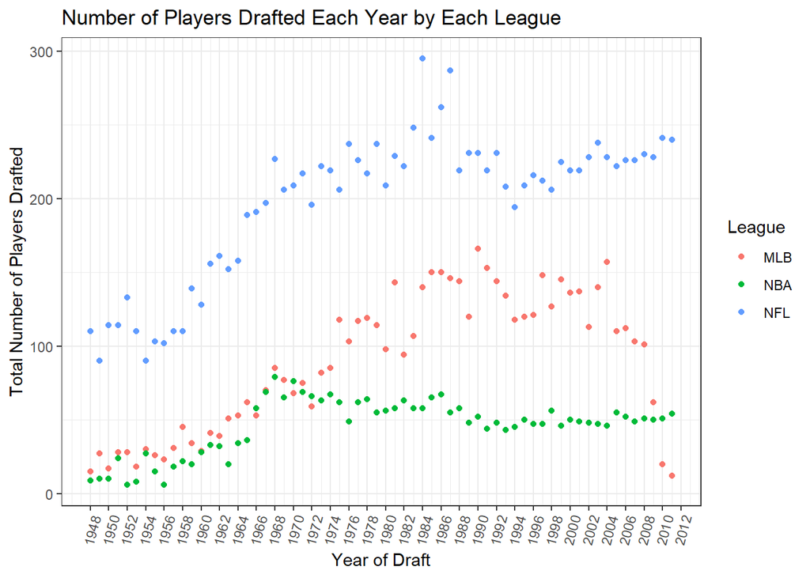

```r
Sport_Draft_counts <- count(data, League, DraftYear) %>%
  na.omit() %>%
  filter(
    DraftYear < 2012,
    DraftYear >1947,
    DraftYear != "1st"
  )

 Sport_Draft_counts$DraftYear <- as.numeric(Sport_Draft_counts$DraftYear)

ggplot(Sport_Draft_counts)+
  geom_point(mapping = aes(x = DraftYear, y = n, color = League)) +
  theme_bw()+
   theme(
    axis.text.x = element_text(angle = 75, hjust = 1)
  )+
    labs(x = "Year of Draft",
       y = "Total Number of Players Drafted",
       title = "Number of Players Drafted Each Year by Each League")+
  scale_x_continuous(breaks = seq(from = 1948, to = 2012, by = 2))
```

## Breakdown of Colleges

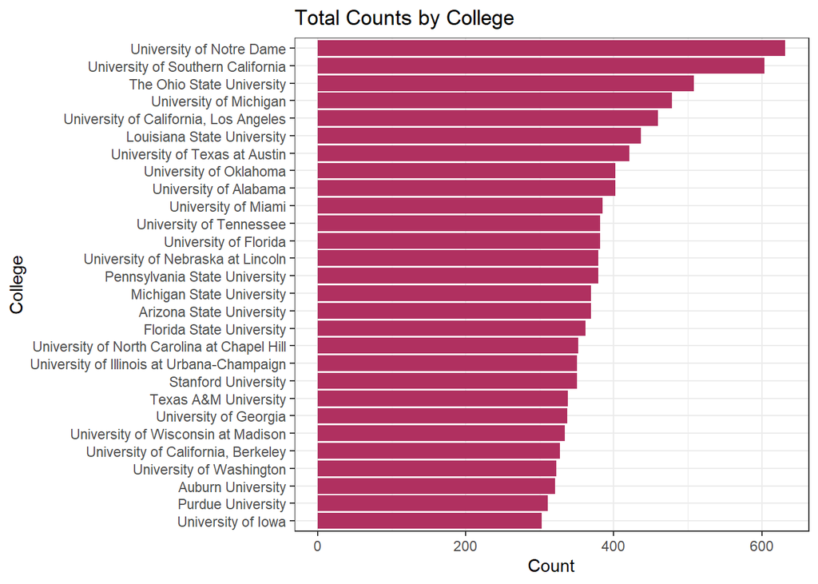

```r
collegecounts <- count(data, College, Lat, Lon) %>%
  filter(
    College != "none",
    College != "na",
    College != "None"
  ) %>%
  na.omit()

ggplot(collegecounts %>%
         filter(
           n > 300
         )) +
  geom_col(mapping = aes(x = reorder(College,n), y = n), fill = "maroon") +
  coord_flip() +
  theme_bw()+
  labs(x = "College",
       y = "Count",
       title = "Total Counts by College"
  )
```

You can see that Notre Dame and USC are far and away producing the most professional athletes. This data is skewed though, due to the large amount of football players in contrast to the other sports. There are 25,000 NFL players in this dataset while the NBA has about 5,000 and MLB has about 7,000.

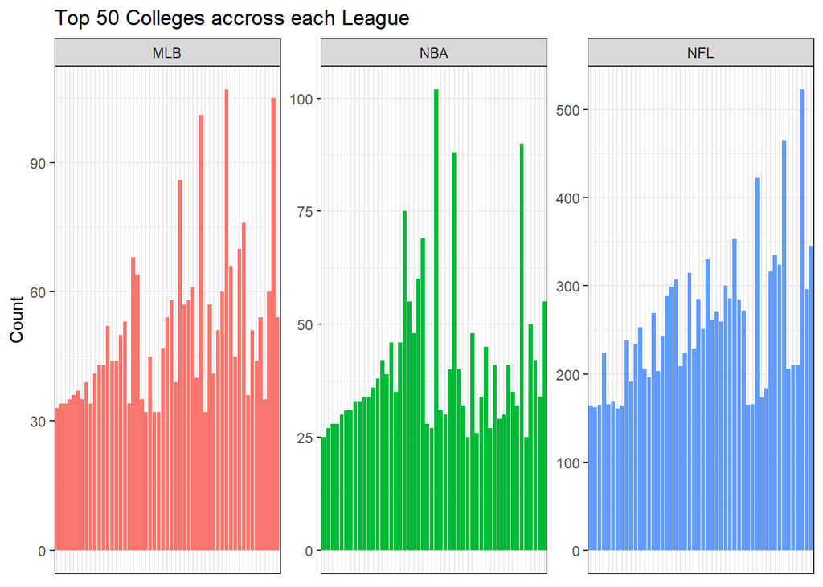

```r
collegecountsbysport <- count(data, College, League) %>%
  filter(
    College != "none",
    College != "na",
    College != "None"
  ) %>%
  na.omit()


top50sport <- collegecountsbysport %>%
  group_by(League)%>%
  slice_max(order_by = n, n = 50) %>%
  mutate(rank = rank(-n))


ggplot(top50sport) +
  geom_col(mapping = aes(x = reorder(College,n), y = n, fill = League) ) +
  facet_wrap(~League,scales = "free") +
  theme_bw()+
  theme(
    axis.text.x = element_blank(),
    axis.title.x = element_blank(),
    axis.ticks.x = element_blank(),
    legend.position = "none")+
  labs(y = "Count",
       title = "Top 50 Colleges accross each League")
```

## Percent of Leauge

```r
top10sport <- collegecountsbysport %>%
  group_by(League)%>%
  slice_max(order_by = n, n = 10) %>%
  mutate(rank = rank(-n))


## put image in

top10percent <- top10sport %>%
  mutate(
    percent_of_league = case_when(
      League == "MLB" ~ n/7550,
      League == "NFL" ~ n/25018,
      League == "NBA" ~ n/4685
    )
  )

top10percent <- arrange(top10percent, -percent_of_league)

kable(top10percent[1:10,], caption = "Percent of Leagues")
```

Percent of Leagues

| College | League | n | rank | percent_of_league |
| --- | --- | --- | --- | --- |
| University of Kentucky | NBA | 102 | 1 | 0.0217716 |
| University of Notre Dame | NFL | 523 | 1 | 0.0209049 |
| University of California, Los Angeles | NBA | 90 | 2 | 0.0192102 |
| University of North Carolina at Chapel Hill | NBA | 88 | 3 | 0.0187834 |
| University of Southern California | NFL | 465 | 2 | 0.0185866 |
| The Ohio State University | NFL | 422 | 3 | 0.0168679 |
| Duke University | NBA | 75 | 4 | 0.0160085 |
| University of Kansas | NBA | 69 | 5 | 0.0147279 |
| University of Texas at Austin | MLB | 107 | 1 | 0.0141722 |
| University of Michigan | NFL | 353 | 4 | 0.0141098 |

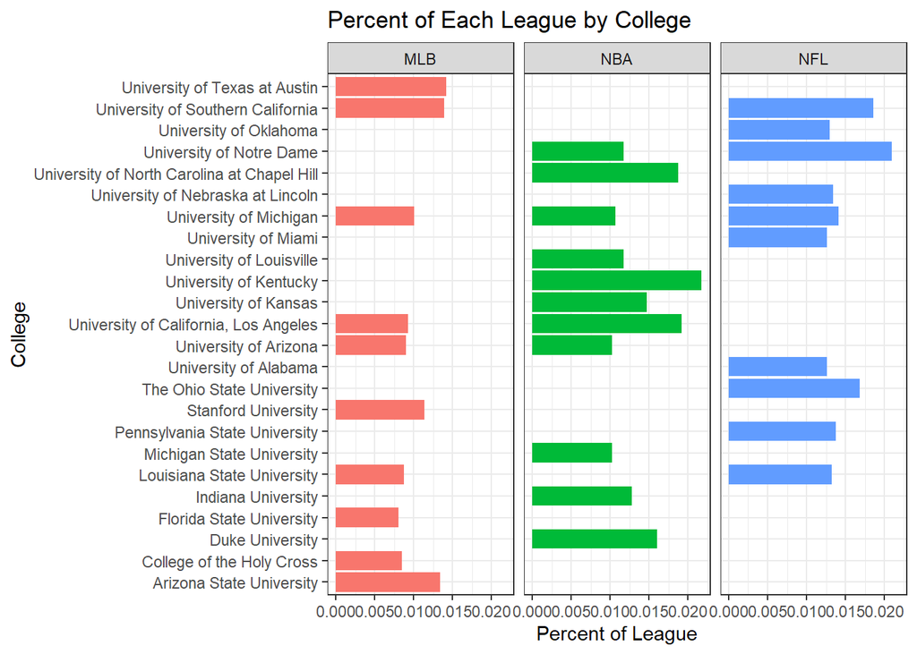

```r
ggplot(top10percent) +
  geom_col(mapping = aes(x = College, y = percent_of_league, fill = League))+
  facet_wrap(~League) +
  coord_flip() +
  labs(x = "College",
       y = "Percent of League",
       title = "Percent of Each League by College")+
  theme_bw()+
  theme(
    legend.position = "none")
```

## Ranks

```r
collegecountsbysport <- count(data, College, League, Conference) %>%
  filter(
    College != "none",
    College != "na",
    College != "None"
  ) %>%
  na.omit()


topcollege <- collegecountsbysport %>%
  group_by(League)%>%
  slice_max(order_by = n, n = 1000) %>%
  mutate(rank = rank(-n)) %>%
  select(-n) %>%
  pivot_wider(names_from = League, values_from = rank)

topcollege$finalrank <- topcollege$MLB+topcollege$NFL+topcollege$NBA

topcollegev2 <- topcollege %>%
  mutate(rank = rank(finalrank)) %>%
  filter(rank < 51)


finalrank <- arrange(topcollegev2,rank)


kable(finalrank[1:20,], caption = "Final Ranking System")
```

Final Ranking System

| College | Conference | MLB | NBA | NFL | finalrank | rank |
| --- | --- | --- | --- | --- | --- | --- |
| University of Michigan | BIG10 | 5.0 | 9.0 | 4.0 | 18.0 | 1 |
| University of California, Los Angeles | PAC12 | 6.0 | 2.0 | 11.0 | 19.0 | 2 |
| University of Southern California | PAC12 | 2.0 | 17.5 | 2.0 | 21.5 | 3 |
| University of Notre Dame | ACC | 14.0 | 7.5 | 1.0 | 22.5 | 4 |
| The Ohio State University | BIG10 | 20.5 | 13.5 | 3.0 | 37.0 | 5 |
| University of Texas at Austin | BIG12 | 1.0 | 24.0 | 16.0 | 41.0 | 6 |
| University of North Carolina at Chapel Hill | ACC | 10.5 | 3.0 | 30.5 | 44.0 | 7 |
| University of Alabama | SEC | 8.5 | 27.5 | 9.0 | 45.0 | 8 |
| Stanford University | PAC12 | 4.0 | 22.0 | 23.0 | 49.0 | 9 |
| University of Tennessee | SEC | 22.0 | 17.5 | 10.0 | 49.5 | 10 |
| University of California, Berkeley | PAC12 | 10.5 | 20.0 | 22.0 | 52.5 | 11 |
| University of Florida | SEC | 12.0 | 29.0 | 12.0 | 53.0 | 12 |
| Arizona State University | PAC12 | 3.0 | 30.5 | 21.0 | 54.5 | 13 |
| Michigan State University | BIG10 | 30.5 | 10.5 | 14.0 | 55.0 | 14 |
| University of Oklahoma | BIG12 | 8.5 | 43.5 | 7.0 | 59.0 | 15 |
| University of Arizona | PAC12 | 7.0 | 10.5 | 44.0 | 61.5 | 16 |
| University of Arkansas | SEC | 18.5 | 27.5 | 25.0 | 71.0 | 17 |
| University of Miami | ACC | 14.0 | 49.5 | 8.0 | 71.5 | 18 |
| University of Minnesota | BIG10 | 34.0 | 15.0 | 24.0 | 73.0 | 19 |
| University of Kentucky | SEC | 35.0 | 1.0 | 45.5 | 81.5 | 20 |

I came up with my own simple formula to determine the top school. I took the rank for each school in each sport and added it up and ranked the lowest total #1 and so on.

## Breakdown by Conference

[figure not shown]

```r
dataConf <- data

dataConf$num <- 1

byConf <- dataConf %>%
  group_by(Conference, League) %>%
    summarise(
      Total = sum(num)
    ) %>%
  na.omit()


ggplot(data = byConf, aes(x = Conference, y = Total))+
  geom_col(aes(fill = League))+
  facet_wrap(~League, scales = "free") +
  theme_bw()+
  theme() +
  coord_flip()
```

```r
collegecountsbysport <- count(data, College, League, Lat, Lon, Conference) %>%
  filter(
    College != "none",
    College != "na",
    College != "None"
  ) %>%
  na.omit()


topcollege <- collegecountsbysport %>%
  group_by(League)%>%
  slice_max(order_by = n, n = 1000) %>%
  mutate(rank = rank(-n)) %>%
  select(-n) %>%
  pivot_wider(names_from = League, values_from = rank)

topcollege$finalrank <- topcollege$MLB+topcollege$NFL+topcollege$NBA

topcollegev2 <- topcollege %>%
  mutate(rank = rank(finalrank)) %>%
  filter(rank < 51)


top50 <- topcollegev2 %>%
  select(rank, College,Lat, Lon, Conference)

top50coordinates <- read_csv("top50.csv")

mapStates = map("state", fill = TRUE, plot = FALSE)

leaflet(data = mapStates) %>% addTiles() %>%
  addPolygons(fillColor = "white", stroke = FALSE) %>%
  addMarkers(data = top50,
             label = c(top50$rank,top50$College),
             labelOptions = labelOptions(noHide = T),
             clusterOptions = markerClusterOptions(),
             clusterId = "quakesCluster")
```

[interactive chart not shown]

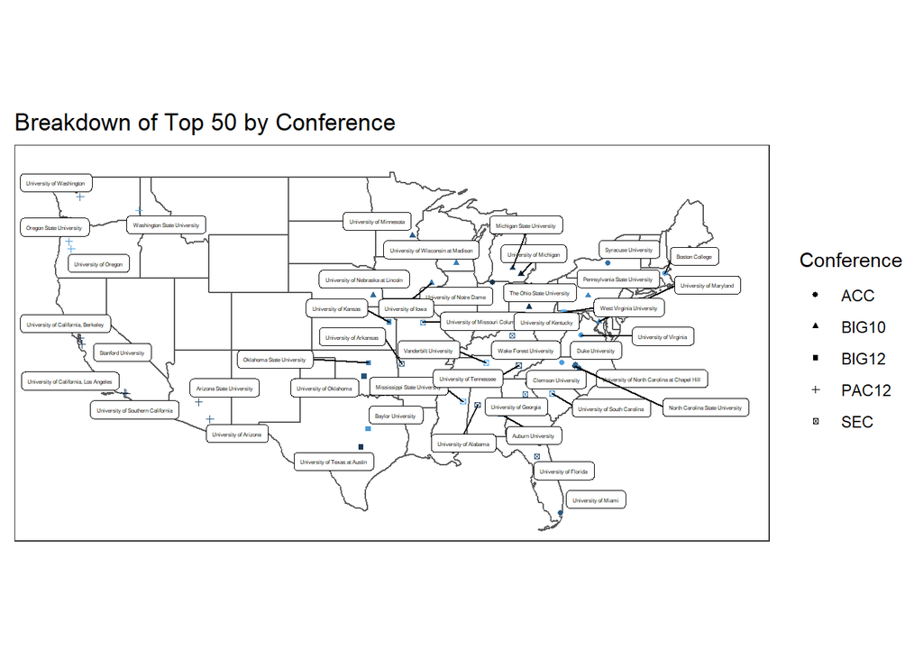

```r
library(ggsflabel)
library(ggrepel)

top50coordinates <- read.csv("top50.csv")

top50v1 <- top50coordinates %>%
  mutate(geometry = gsub("c", "", geometry)) %>%
  mutate(geometry = gsub("\\(", "", geometry)) %>%
  mutate(geometry = gsub("\\)", "", geometry)) %>%
  mutate(geometry = str_trim(geometry)) %>%
  separate(geometry, c("lat", "long"), " ") %>%
  mutate(lat = as.numeric(lat),
         long = as.numeric(long))


states <- us_states()

ggplot()+
  geom_sf(data = states, fill = NA) +
  geom_point(data = top50v1, mapping = aes(x = lat, y = long, shape = Conference, color = rank), size = 1)+
  theme_bw()+
  guides(color = FALSE)+
  coord_sf(xlim = c(-125,-65), ylim = c(25,50))+
  labs(color = "Conference",
       title = "Breakdown of Top 50 by Conference")+
  theme(
    axis.text = element_blank(),
    axis.ticks = element_blank(),
    axis.title = element_blank(),
    panel.grid = element_blank()
  )+
  geom_label_repel(data = top50v1, aes(x = lat, y = long, label = c(College)),size = 1, box.padding = 0.2)
```

The majority of the darker shades, which did indicate a better rank, are located on the eastern side of the country and in some cases clustered up.

## Conclusion

After looking at all these I have come to conclude that the University of Michigan, UCLA, USC, and Notre Dame have been the top producers of professional athletes due to their high ranks and amount of athletes across each sport.

## Future Plans

In the future I would like to try and find more data sets that have better data on High Schools attended as well as whole datasets for hockey, soccer, and women’s sports. Finding and merging all these together can help me fully understand where the talent is best produced. I want to also look more at high schools and places of birth once I get more data to understand that better as well. I also want to find better Draft data so I can look at where the top talent is coming from historically. Salary and longevity are two other variables that I am interested in diving into to find significance theree.

For questions or comments, I can be reached at bradymonks@gmail.com